# Risk Factor Analysis

## Outcome Variable

**Outcome Variable:** sstunted

## Predictor Variables

**Intervention Variable:** hfoodsec

**Adjustment Set:**

- arm
- sex
- W_mage
- meducyrs
- feducyrs
- hhwealth_quart
- vagbrth
- W_nrooms
- W_nchldlt5
- brthmon
- W_parity
- impfloor
- impsan
- safeh20
- delta_W_mage
- delta_meducyrs
- delta_feducyrs
- delta_hhwealth_quart
- delta_vagbrth
- delta_W_nrooms
- delta_W_nchldlt5
- delta_brthmon
- delta_W_parity
- delta_impfloor
- delta_impsan
- delta_safeh20

## Stratifying Variables

The analysis was stratified on these variable(s):

- agecat
- studyid
- country

## Data Summary

| agecat | studyid | country | hfoodsec | sstunted | n_cell | n |
| --- | --- | --- | --- | --- | --- | --- |
| Birth | ki0047075b-MAL-ED | BANGLADESH | Food Secure | 0 | 153 | 188 |
| Birth | ki0047075b-MAL-ED | BANGLADESH | Food Secure | 1 | 4 | 188 |
| Birth | ki0047075b-MAL-ED | BANGLADESH | Mildly Food Insecure | 0 | 3 | 188 |
| Birth | ki0047075b-MAL-ED | BANGLADESH | Mildly Food Insecure | 1 | 1 | 188 |
| Birth | ki0047075b-MAL-ED | BANGLADESH | Food Insecure | 0 | 26 | 188 |
| Birth | ki0047075b-MAL-ED | BANGLADESH | Food Insecure | 1 | 1 | 188 |
| Birth | ki0047075b-MAL-ED | BRAZIL | Food Secure | 0 | 0 | 105 |
| Birth | ki0047075b-MAL-ED | BRAZIL | Food Secure | 1 | 0 | 105 |
| Birth | ki0047075b-MAL-ED | BRAZIL | Mildly Food Insecure | 0 | 11 | 105 |
| Birth | ki0047075b-MAL-ED | BRAZIL | Mildly Food Insecure | 1 | 0 | 105 |
| Birth | ki0047075b-MAL-ED | BRAZIL | Food Insecure | 0 | 90 | 105 |
| Birth | ki0047075b-MAL-ED | BRAZIL | Food Insecure | 1 | 4 | 105 |
| Birth | ki0047075b-MAL-ED | INDIA | Food Secure | 0 | 150 | 170 |
| Birth | ki0047075b-MAL-ED | INDIA | Food Secure | 1 | 4 | 170 |
| Birth | ki0047075b-MAL-ED | INDIA | Mildly Food Insecure | 0 | 2 | 170 |
| Birth | ki0047075b-MAL-ED | INDIA | Mildly Food Insecure | 1 | 0 | 170 |
| Birth | ki0047075b-MAL-ED | INDIA | Food Insecure | 0 | 13 | 170 |
| Birth | ki0047075b-MAL-ED | INDIA | Food Insecure | 1 | 1 | 170 |
| Birth | ki0047075b-MAL-ED | NEPAL | Food Secure | 0 | 76 | 98 |
| Birth | ki0047075b-MAL-ED | NEPAL | Food Secure | 1 | 0 | 98 |
| Birth | ki0047075b-MAL-ED | NEPAL | Mildly Food Insecure | 0 | 9 | 98 |
| Birth | ki0047075b-MAL-ED | NEPAL | Mildly Food Insecure | 1 | 0 | 98 |
| Birth | ki0047075b-MAL-ED | NEPAL | Food Insecure | 0 | 11 | 98 |
| Birth | ki0047075b-MAL-ED | NEPAL | Food Insecure | 1 | 2 | 98 |
| Birth | ki0047075b-MAL-ED | PERU | Food Secure | 0 | 27 | 107 |
| Birth | ki0047075b-MAL-ED | PERU | Food Secure | 1 | 0 | 107 |
| Birth | ki0047075b-MAL-ED | PERU | Mildly Food Insecure | 0 | 25 | 107 |
| Birth | ki0047075b-MAL-ED | PERU | Mildly Food Insecure | 1 | 0 | 107 |
| Birth | ki0047075b-MAL-ED | PERU | Food Insecure | 0 | 55 | 107 |
| Birth | ki0047075b-MAL-ED | PERU | Food Insecure | 1 | 0 | 107 |

[output cut: 162 more lines]

The following strata were considered:

- agecat: 24 months, studyid: ki0047075b-MAL-ED, country: BANGLADESH
- agecat: 24 months, studyid: ki0047075b-MAL-ED, country: BRAZIL
- agecat: 24 months, studyid: ki0047075b-MAL-ED, country: INDIA
- agecat: 24 months, studyid: ki0047075b-MAL-ED, country: NEPAL
- agecat: 24 months, studyid: ki0047075b-MAL-ED, country: PERU
- agecat: 24 months, studyid: ki0047075b-MAL-ED, country: SOUTH AFRICA
- agecat: 24 months, studyid: ki1017093-NIH-Birth, country: BANGLADESH
- agecat: 24 months, studyid: ki1017093c-NIH-Crypto, country: BANGLADESH
- agecat: 24 months, studyid: ki1113344-GMS-Nepal, country: NEPAL
- agecat: 24 months, studyid: kiGH5241-JiVitA-3, country: BANGLADESH
- agecat: 24 months, studyid: kiGH5241-JiVitA-4, country: BANGLADESH
- agecat: 6 months, studyid: ki0047075b-MAL-ED, country: BANGLADESH
- agecat: 6 months, studyid: ki0047075b-MAL-ED, country: BRAZIL
- agecat: 6 months, studyid: ki0047075b-MAL-ED, country: INDIA
- agecat: 6 months, studyid: ki0047075b-MAL-ED, country: NEPAL
- agecat: 6 months, studyid: ki0047075b-MAL-ED, country: PERU
- agecat: 6 months, studyid: ki0047075b-MAL-ED, country: SOUTH AFRICA
- agecat: 6 months, studyid: ki1017093-NIH-Birth, country: BANGLADESH
- agecat: 6 months, studyid: ki1017093c-NIH-Crypto, country: BANGLADESH
- agecat: 6 months, studyid: ki1113344-GMS-Nepal, country: NEPAL
- agecat: 6 months, studyid: kiGH5241-JiVitA-3, country: BANGLADESH
- agecat: 6 months, studyid: kiGH5241-JiVitA-4, country: BANGLADESH
- agecat: Birth, studyid: ki0047075b-MAL-ED, country: BANGLADESH
- agecat: Birth, studyid: ki0047075b-MAL-ED, country: BRAZIL
- agecat: Birth, studyid: ki0047075b-MAL-ED, country: INDIA
- agecat: Birth, studyid: ki0047075b-MAL-ED, country: NEPAL
- agecat: Birth, studyid: ki0047075b-MAL-ED, country: PERU
- agecat: Birth, studyid: ki0047075b-MAL-ED, country: SOUTH AFRICA
- agecat: Birth, studyid: ki1017093-NIH-Birth, country: BANGLADESH
- agecat: Birth, studyid: ki1017093c-NIH-Crypto, country: BANGLADESH
- agecat: Birth, studyid: kiGH5241-JiVitA-3, country: BANGLADESH
- agecat: Birth, studyid: kiGH5241-JiVitA-4, country: BANGLADESH

### Dropped Strata

Some strata were dropped due to rare outcomes:

- agecat: Birth, studyid: ki0047075b-MAL-ED, country: BANGLADESH
- agecat: Birth, studyid: ki0047075b-MAL-ED, country: BRAZIL
- agecat: Birth, studyid: ki0047075b-MAL-ED, country: INDIA
- agecat: Birth, studyid: ki0047075b-MAL-ED, country: NEPAL
- agecat: Birth, studyid: ki0047075b-MAL-ED, country: PERU
- agecat: Birth, studyid: ki0047075b-MAL-ED, country: SOUTH AFRICA
- agecat: Birth, studyid: ki1017093-NIH-Birth, country: BANGLADESH
- agecat: Birth, studyid: ki1017093c-NIH-Crypto, country: BANGLADESH
- agecat: 6 months, studyid: ki0047075b-MAL-ED, country: BANGLADESH
- agecat: 6 months, studyid: ki0047075b-MAL-ED, country: BRAZIL
- agecat: 6 months, studyid: ki0047075b-MAL-ED, country: INDIA
- agecat: 6 months, studyid: ki0047075b-MAL-ED, country: NEPAL
- agecat: 6 months, studyid: ki0047075b-MAL-ED, country: PERU
- agecat: 6 months, studyid: ki0047075b-MAL-ED, country: SOUTH AFRICA
- agecat: 6 months, studyid: ki1017093-NIH-Birth, country: BANGLADESH
- agecat: 6 months, studyid: ki1017093c-NIH-Crypto, country: BANGLADESH
- agecat: 24 months, studyid: ki0047075b-MAL-ED, country: BANGLADESH
- agecat: 24 months, studyid: ki0047075b-MAL-ED, country: BRAZIL
- agecat: 24 months, studyid: ki0047075b-MAL-ED, country: INDIA
- agecat: 24 months, studyid: ki0047075b-MAL-ED, country: NEPAL
- agecat: 24 months, studyid: ki0047075b-MAL-ED, country: PERU
- agecat: 24 months, studyid: ki0047075b-MAL-ED, country: SOUTH AFRICA

## Methods Detail

We’re interested in the causal parameters $E[Y_a]$ for all values of $a \in \mathcal{A}$. These parameters represent the mean outcome if, possibly contrary to fact, we intervened to set all units to have $A=a$. Under the randomization and positivity assumptions, these are identified by the statistical parameters $\psi_a=E_W[E_{Y|A,W}(Y|A=a,W)]$. In addition, we’re interested in the mean of $Y$, $E[Y]$ under no intervention (the observed mean). We will estimate these parameters by using SuperLearner to fit the relevant likelihood factors – $E_{Y|A,W}(Y|A=a,W)$ and $p(A=a|W)$, and then updating our likelihood fit using a joint TMLE.

For unadjusted analyses ($W=\{\}$), initial likelihoods were estimated using Lrnr_glm to estimate the simple $E(Y|A)$ and Lrnr_mean to estimate $p(A)$. For adjusted analyses, a small library containing Lrnr_glmnet, Lrnr_xgboost, and Lrnr_mean was used.

Having estimated these parameters, we will then use the delta method to estimate relative risks and attributable risks relative to a prespecified baseline level of $A$.

# Results Detail

## Results Plots

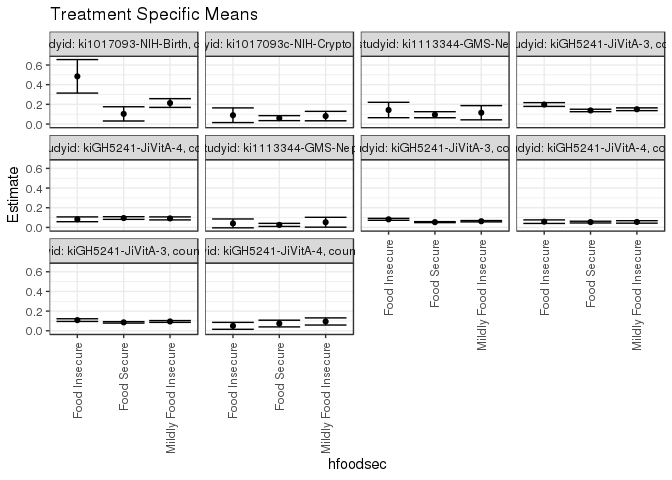

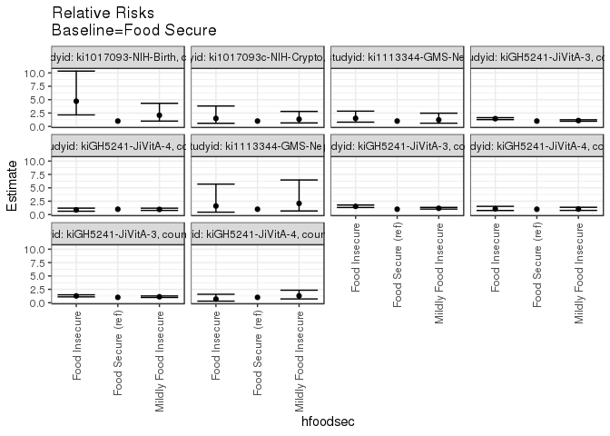

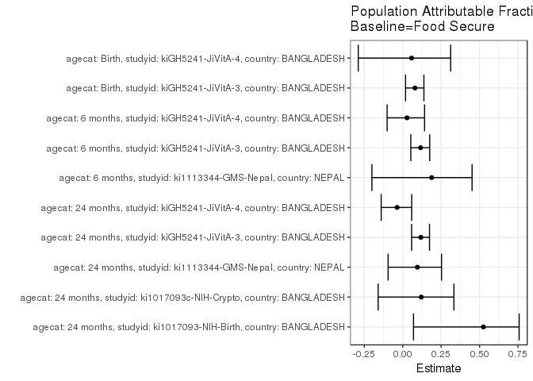

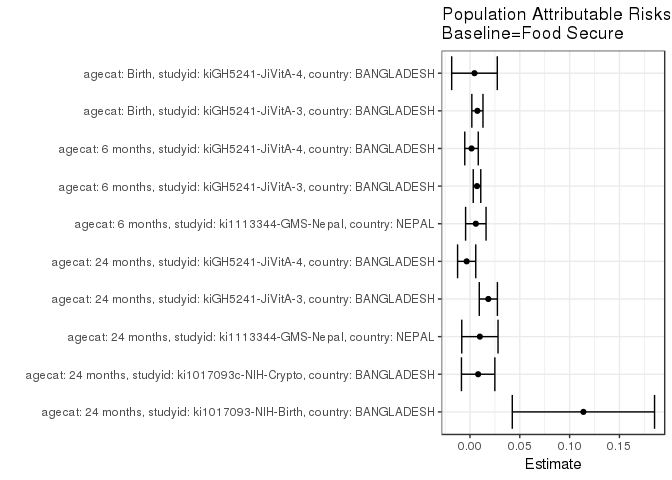

## Results Table

### Parameter: TSM

| agecat | studyid | country | intervention_level | baseline_level | estimate | ci_lower | ci_upper |
| --- | --- | --- | --- | --- | --- | --- | --- |
| Birth | kiGH5241-JiVitA-3 | BANGLADESH | Food Secure | NA | 0.0856732 | 0.0782144 | 0.0931319 |
| Birth | kiGH5241-JiVitA-3 | BANGLADESH | Mildly Food Insecure | NA | 0.0949174 | 0.0859602 | 0.1038745 |
| Birth | kiGH5241-JiVitA-3 | BANGLADESH | Food Insecure | NA | 0.1085673 | 0.0949218 | 0.1222128 |
| Birth | kiGH5241-JiVitA-4 | BANGLADESH | Food Secure | NA | 0.0736157 | 0.0396806 | 0.1075509 |
| Birth | kiGH5241-JiVitA-4 | BANGLADESH | Mildly Food Insecure | NA | 0.0946642 | 0.0582890 | 0.1310394 |
| Birth | kiGH5241-JiVitA-4 | BANGLADESH | Food Insecure | NA | 0.0503546 | 0.0150092 | 0.0857000 |
| 6 months | ki1113344-GMS-Nepal | NEPAL | Food Secure | NA | 0.0253165 | 0.0098111 | 0.0408218 |
| 6 months | ki1113344-GMS-Nepal | NEPAL | Mildly Food Insecure | NA | 0.0526316 | 0.0023831 | 0.1028800 |
| 6 months | ki1113344-GMS-Nepal | NEPAL | Food Insecure | NA | 0.0405405 | -0.0044363 | 0.0855174 |
| 6 months | kiGH5241-JiVitA-3 | BANGLADESH | Food Secure | NA | 0.0536198 | 0.0486751 | 0.0585644 |
| 6 months | kiGH5241-JiVitA-3 | BANGLADESH | Mildly Food Insecure | NA | 0.0627711 | 0.0562308 | 0.0693115 |
| 6 months | kiGH5241-JiVitA-3 | BANGLADESH | Food Insecure | NA | 0.0821679 | 0.0723116 | 0.0920241 |
| 6 months | kiGH5241-JiVitA-4 | BANGLADESH | Food Secure | NA | 0.0539931 | 0.0450555 | 0.0629306 |
| 6 months | kiGH5241-JiVitA-4 | BANGLADESH | Mildly Food Insecure | NA | 0.0554831 | 0.0428399 | 0.0681263 |
| 6 months | kiGH5241-JiVitA-4 | BANGLADESH | Food Insecure | NA | 0.0582981 | 0.0402381 | 0.0763581 |
| 24 months | ki1017093-NIH-Birth | BANGLADESH | Food Secure | NA | 0.1029412 | 0.0306300 | 0.1752524 |
| 24 months | ki1017093-NIH-Birth | BANGLADESH | Mildly Food Insecure | NA | 0.2134146 | 0.1690228 | 0.2578065 |
| 24 months | ki1017093-NIH-Birth | BANGLADESH | Food Insecure | NA | 0.4848485 | 0.3141348 | 0.6555622 |
| 24 months | ki1017093c-NIH-Crypto | BANGLADESH | Food Secure | NA | 0.0598802 | 0.0344101 | 0.0853504 |
| 24 months | ki1017093c-NIH-Crypto | BANGLADESH | Mildly Food Insecure | NA | 0.0806452 | 0.0326728 | 0.1286175 |
| 24 months | ki1017093c-NIH-Crypto | BANGLADESH | Food Insecure | NA | 0.0892857 | 0.0145275 | 0.1640439 |
| 24 months | ki1113344-GMS-Nepal | NEPAL | Food Secure | NA | 0.0945552 | 0.0638880 | 0.1252223 |
| 24 months | ki1113344-GMS-Nepal | NEPAL | Mildly Food Insecure | NA | 0.1148141 | 0.0423310 | 0.1872972 |
| 24 months | ki1113344-GMS-Nepal | NEPAL | Food Insecure | NA | 0.1424534 | 0.0643301 | 0.2205767 |
| 24 months | kiGH5241-JiVitA-3 | BANGLADESH | Food Secure | NA | 0.1377374 | 0.1253623 | 0.1501124 |
| 24 months | kiGH5241-JiVitA-3 | BANGLADESH | Mildly Food Insecure | NA | 0.1501287 | 0.1360133 | 0.1642440 |
| 24 months | kiGH5241-JiVitA-3 | BANGLADESH | Food Insecure | NA | 0.1981753 | 0.1790516 | 0.2172991 |
| 24 months | kiGH5241-JiVitA-4 | BANGLADESH | Food Secure | NA | 0.0951221 | 0.0814649 | 0.1087794 |
| 24 months | kiGH5241-JiVitA-4 | BANGLADESH | Mildly Food Insecure | NA | 0.0915019 | 0.0762503 | 0.1067536 |
| 24 months | kiGH5241-JiVitA-4 | BANGLADESH | Food Insecure | NA | 0.0824382 | 0.0581588 | 0.1067177 |

### Parameter: E(Y)

| agecat | studyid | country | intervention_level | baseline_level | estimate | ci_lower | ci_upper |
| --- | --- | --- | --- | --- | --- | --- | --- |
| Birth | kiGH5241-JiVitA-3 | BANGLADESH | NA | NA | 0.0931376 | 0.0875494 | 0.0987258 |
| Birth | kiGH5241-JiVitA-4 | BANGLADESH | NA | NA | 0.0781441 | 0.0560930 | 0.1001951 |
| 6 months | ki1113344-GMS-Nepal | NEPAL | NA | NA | 0.0311927 | 0.0165846 | 0.0458008 |
| 6 months | kiGH5241-JiVitA-3 | BANGLADESH | NA | NA | 0.0606792 | 0.0568149 | 0.0645436 |
| 6 months | kiGH5241-JiVitA-4 | BANGLADESH | NA | NA | 0.0555437 | 0.0486186 | 0.0624688 |
| 24 months | ki1017093-NIH-Birth | BANGLADESH | NA | NA | 0.2167832 | 0.1777459 | 0.2558205 |
| 24 months | ki1017093c-NIH-Crypto | BANGLADESH | NA | NA | 0.0680934 | 0.0462948 | 0.0898920 |
| 24 months | ki1113344-GMS-Nepal | NEPAL | NA | NA | 0.1045082 | 0.0773382 | 0.1316782 |
| 24 months | kiGH5241-JiVitA-3 | BANGLADESH | NA | NA | 0.1561719 | 0.1470652 | 0.1652786 |
| 24 months | kiGH5241-JiVitA-4 | BANGLADESH | NA | NA | 0.0918079 | 0.0822976 | 0.1013182 |

### Parameter: RR

| agecat | studyid | country | intervention_level | baseline_level | estimate | ci_lower | ci_upper |
| --- | --- | --- | --- | --- | --- | --- | --- |
| Birth | kiGH5241-JiVitA-3 | BANGLADESH | Food Secure | Food Secure | 1.0000000 | 1.0000000 | 1.000000 |
| Birth | kiGH5241-JiVitA-3 | BANGLADESH | Mildly Food Insecure | Food Secure | 1.1079006 | 0.9770622 | 1.256260 |
| Birth | kiGH5241-JiVitA-3 | BANGLADESH | Food Insecure | Food Secure | 1.2672260 | 1.0891289 | 1.474446 |
| Birth | kiGH5241-JiVitA-4 | BANGLADESH | Food Secure | Food Secure | 1.0000000 | 1.0000000 | 1.000000 |
| Birth | kiGH5241-JiVitA-4 | BANGLADESH | Mildly Food Insecure | Food Secure | 1.2859233 | 0.7073385 | 2.337776 |
| Birth | kiGH5241-JiVitA-4 | BANGLADESH | Food Insecure | Food Secure | 0.6840193 | 0.2968889 | 1.575951 |
| 6 months | ki1113344-GMS-Nepal | NEPAL | Food Secure | Food Secure | 1.0000000 | 1.0000000 | 1.000000 |
| 6 months | ki1113344-GMS-Nepal | NEPAL | Mildly Food Insecure | Food Secure | 2.0789474 | 0.6686982 | 6.463338 |
| 6 months | ki1113344-GMS-Nepal | NEPAL | Food Insecure | Food Secure | 1.6013514 | 0.4509450 | 5.686560 |
| 6 months | kiGH5241-JiVitA-3 | BANGLADESH | Food Secure | Food Secure | 1.0000000 | 1.0000000 | 1.000000 |
| 6 months | kiGH5241-JiVitA-3 | BANGLADESH | Mildly Food Insecure | Food Secure | 1.1706709 | 1.0228970 | 1.339793 |
| 6 months | kiGH5241-JiVitA-3 | BANGLADESH | Food Insecure | Food Secure | 1.5324173 | 1.3206938 | 1.778083 |
| 6 months | kiGH5241-JiVitA-4 | BANGLADESH | Food Secure | Food Secure | 1.0000000 | 1.0000000 | 1.000000 |
| 6 months | kiGH5241-JiVitA-4 | BANGLADESH | Mildly Food Insecure | Food Secure | 1.0275969 | 0.7768134 | 1.359342 |
| 6 months | kiGH5241-JiVitA-4 | BANGLADESH | Food Insecure | Food Secure | 1.0797334 | 0.7579043 | 1.538221 |
| 24 months | ki1017093-NIH-Birth | BANGLADESH | Food Secure | Food Secure | 1.0000000 | 1.0000000 | 1.000000 |
| 24 months | ki1017093-NIH-Birth | BANGLADESH | Mildly Food Insecure | Food Secure | 2.0731707 | 0.9964838 | 4.313203 |
| 24 months | ki1017093-NIH-Birth | BANGLADESH | Food Insecure | Food Secure | 4.7099567 | 2.1466835 | 10.333937 |
| 24 months | ki1017093c-NIH-Crypto | BANGLADESH | Food Secure | Food Secure | 1.0000000 | 1.0000000 | 1.000000 |
| 24 months | ki1017093c-NIH-Crypto | BANGLADESH | Mildly Food Insecure | Food Secure | 1.3467742 | 0.6481889 | 2.798260 |
| 24 months | ki1017093c-NIH-Crypto | BANGLADESH | Food Insecure | Food Secure | 1.4910714 | 0.5829558 | 3.813829 |
| 24 months | ki1113344-GMS-Nepal | NEPAL | Food Secure | Food Secure | 1.0000000 | 1.0000000 | 1.000000 |
| 24 months | ki1113344-GMS-Nepal | NEPAL | Mildly Food Insecure | Food Secure | 1.2142554 | 0.5971502 | 2.469088 |
| 24 months | ki1113344-GMS-Nepal | NEPAL | Food Insecure | Food Secure | 1.5065640 | 0.7966787 | 2.848997 |
| 24 months | kiGH5241-JiVitA-3 | BANGLADESH | Food Secure | Food Secure | 1.0000000 | 1.0000000 | 1.000000 |
| 24 months | kiGH5241-JiVitA-3 | BANGLADESH | Mildly Food Insecure | Food Secure | 1.0899632 | 0.9613428 | 1.235792 |
| 24 months | kiGH5241-JiVitA-3 | BANGLADESH | Food Insecure | Food Secure | 1.4387914 | 1.2669057 | 1.633998 |
| 24 months | kiGH5241-JiVitA-4 | BANGLADESH | Food Secure | Food Secure | 1.0000000 | 1.0000000 | 1.000000 |
| 24 months | kiGH5241-JiVitA-4 | BANGLADESH | Mildly Food Insecure | Food Secure | 0.9619416 | 0.7737323 | 1.195933 |
| 24 months | kiGH5241-JiVitA-4 | BANGLADESH | Food Insecure | Food Secure | 0.8666567 | 0.6252128 | 1.201341 |

### Parameter: PAR

| agecat | studyid | country | intervention_level | baseline_level | estimate | ci_lower | ci_upper |
| --- | --- | --- | --- | --- | --- | --- | --- |
| Birth | kiGH5241-JiVitA-3 | BANGLADESH | Food Secure | NA | 0.0074645 | 0.0018742 | 0.0130548 |
| Birth | kiGH5241-JiVitA-4 | BANGLADESH | Food Secure | NA | 0.0045283 | -0.0183551 | 0.0274118 |
| 6 months | ki1113344-GMS-Nepal | NEPAL | Food Secure | NA | 0.0058762 | -0.0043863 | 0.0161387 |
| 6 months | kiGH5241-JiVitA-3 | BANGLADESH | Food Secure | NA | 0.0070595 | 0.0032868 | 0.0108322 |
| 6 months | kiGH5241-JiVitA-4 | BANGLADESH | Food Secure | NA | 0.0015507 | -0.0052235 | 0.0083248 |
| 24 months | ki1017093-NIH-Birth | BANGLADESH | Food Secure | NA | 0.1138420 | 0.0424616 | 0.1852225 |
| 24 months | ki1017093c-NIH-Crypto | BANGLADESH | Food Secure | NA | 0.0082131 | -0.0085443 | 0.0249706 |
| 24 months | ki1113344-GMS-Nepal | NEPAL | Food Secure | NA | 0.0099530 | -0.0082449 | 0.0281510 |
| 24 months | kiGH5241-JiVitA-3 | BANGLADESH | Food Secure | NA | 0.0184345 | 0.0093358 | 0.0275332 |
| 24 months | kiGH5241-JiVitA-4 | BANGLADESH | Food Secure | NA | -0.0033142 | -0.0124308 | 0.0058023 |

### Parameter: PAF

| agecat | studyid | country | intervention_level | baseline_level | estimate | ci_lower | ci_upper |
| --- | --- | --- | --- | --- | --- | --- | --- |
| Birth | kiGH5241-JiVitA-3 | BANGLADESH | Food Secure | NA | 0.0801444 | 0.0184786 | 0.1379359 |
| Birth | kiGH5241-JiVitA-4 | BANGLADESH | Food Secure | NA | 0.0579486 | -0.2892525 | 0.3116470 |
| 6 months | ki1113344-GMS-Nepal | NEPAL | Food Secure | NA | 0.1883842 | -0.2003166 | 0.4512113 |
| 6 months | kiGH5241-JiVitA-3 | BANGLADESH | Food Secure | NA | 0.1163408 | 0.0527436 | 0.1756682 |
| 6 months | kiGH5241-JiVitA-4 | BANGLADESH | Food Secure | NA | 0.0279178 | -0.1014923 | 0.1421240 |
| 24 months | ki1017093-NIH-Birth | BANGLADESH | Food Secure | NA | 0.5251423 | 0.0701575 | 0.7574968 |
| 24 months | ki1017093c-NIH-Crypto | BANGLADESH | Food Secure | NA | 0.1206159 | -0.1598580 | 0.3332663 |
| 24 months | ki1113344-GMS-Nepal | NEPAL | Food Secure | NA | 0.0952369 | -0.0949926 | 0.2524185 |
| 24 months | kiGH5241-JiVitA-3 | BANGLADESH | Food Secure | NA | 0.1180400 | 0.0579357 | 0.1743096 |
| 24 months | kiGH5241-JiVitA-4 | BANGLADESH | Food Secure | NA | -0.0360997 | -0.1400837 | 0.0584003 |